# R Notebook

```r
# loading libraries
library(here, quietly=T)
library(dplyr, quietly=T)
library(tidyr, quietly=T)
library(ggplot2, quietly=T)
library(MNP, quietly=T)
library(nnet, quietly=T)
library(janitor, quietly = T)
library(arm, quietly=T)
```

Vamos importar os dados já processados:

```r
here()

# importando dados processados
compartilhamento_3_estudos <- readRDS("Transformados/compartilhamento_3_estudos.rds")
summary(compartilhamento_3_estudos)
```

# Análise Exploratória dos Dados

```r
# amostra por estudo
compartilhamento_3_estudos %>%
  group_by(estudo) %>%
  summarise(amostra_total = n())
```

| estudo | amostra_total |
| --- | --- |
| estudo 1 | 214 |
| estudo 2 | 204 |
| estudo 3 | 204 |

```r
# amostra por estudo e político
compartilhamento_3_estudos %>%
  group_by(estudo, politico) %>%
  summarise(amostra_total = n(), .groups="drop_last") %>%
  mutate(subtotal_estudo = sum(amostra_total),
         perc_politico = round(amostra_total/subtotal_estudo, 2))
```

| estudo | politico | amostra_total | subtotal_estudo | perc_politico |
| --- | --- | --- | --- | --- |
| estudo 1 | neutro | 63 | 214 | 0.29 |
| estudo 1 | Bolsonaro | 48 | 214 | 0.22 |
| estudo 1 | Lula | 103 | 214 | 0.48 |
| estudo 2 | neutro | 43 | 204 | 0.21 |
| estudo 2 | Bolsonaro | 61 | 204 | 0.30 |
| estudo 2 | Lula | 100 | 204 | 0.49 |
| estudo 3 | neutro | 56 | 204 | 0.27 |
| estudo 3 | Bolsonaro | 56 | 204 | 0.27 |
| estudo 3 | Lula | 92 | 204 | 0.45 |

```r
# demográficos por estudo e político

# gênero (percentual por estudo)
compartilhamento_3_estudos %>%
  group_by(genero, estudo) %>%
  summarise(amostra_total = n(), .groups="drop") %>%
  mutate(subtotal_estudo = sum(amostra_total),
         perc_genero = round(amostra_total/subtotal_estudo, 3)) %>%
  arrange(estudo)
```

| genero | estudo | amostra_total | subtotal_estudo | perc_genero |
| --- | --- | --- | --- | --- |
| homem | estudo 1 | 100 | 622 | 0.161 |
| mulher | estudo 1 | 112 | 622 | 0.180 |
| outros | estudo 1 | 2 | 622 | 0.003 |
| homem | estudo 2 | 79 | 622 | 0.127 |
| mulher | estudo 2 | 122 | 622 | 0.196 |
| outros | estudo 2 | 3 | 622 | 0.005 |
| homem | estudo 3 | 99 | 622 | 0.159 |
| mulher | estudo 3 | 104 | 622 | 0.167 |
| outros | estudo 3 | 1 | 622 | 0.002 |

```r
# idade média
compartilhamento_3_estudos %>%
  group_by(estudo, politico) %>%
  summarise(idade_mediana = median(idade), .groups="drop")
```

| estudo | politico | idade_mediana |
| --- | --- | --- |
| estudo 1 | neutro | 34.0 |
| estudo 1 | Bolsonaro | 45.0 |
| estudo 1 | Lula | 27.0 |
| estudo 2 | neutro | 25.0 |
| estudo 2 | Bolsonaro | 37.0 |
| estudo 2 | Lula | 23.5 |
| estudo 3 | neutro | 39.5 |
| estudo 3 | Bolsonaro | 45.0 |
| estudo 3 | Lula | 35.0 |

```r
#
# escolaridade (percentual por estudo)
escol <- compartilhamento_3_estudos %>%
  group_by(grau_de_escolaridade, estudo) %>%
  summarise(amostra_total = n(), .groups="drop") %>%
  mutate(subtotal_estudo = sum(amostra_total),
         perc_escolaridade = round(amostra_total/subtotal_estudo, 3)) %>%
  arrange(estudo)
```

Agora, alguns gráficos

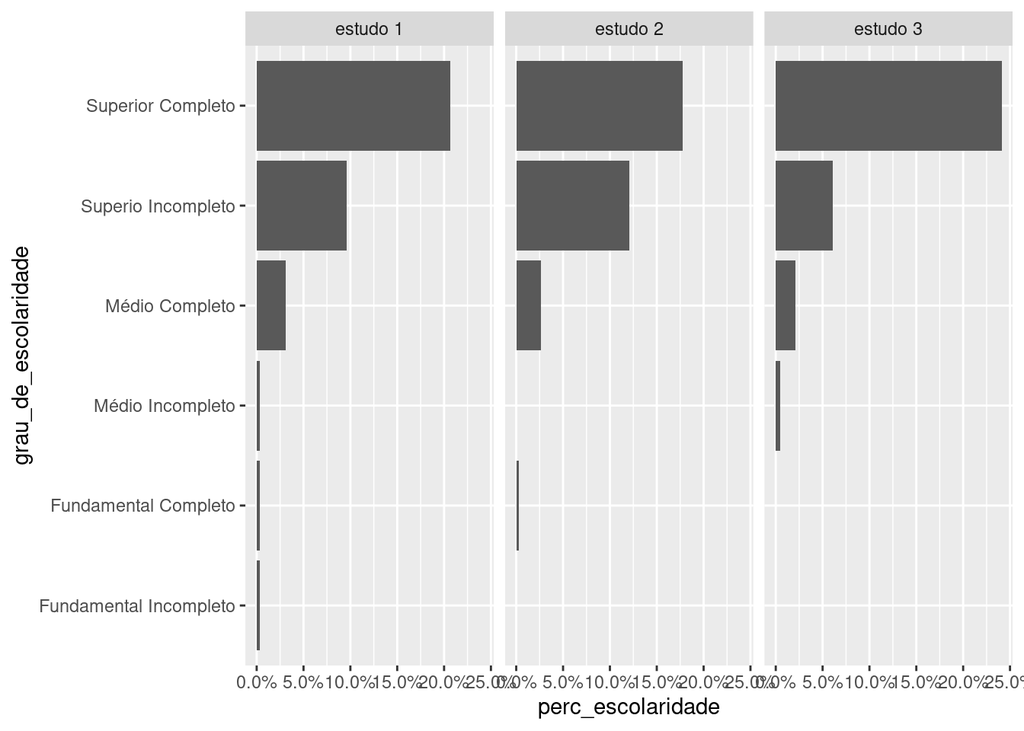

```r
# gráfico de barra de escolaridade

escol %>%
  ggplot(aes(y=perc_escolaridade, x=grau_de_escolaridade)) + geom_col() +
  coord_flip() + scale_y_continuous(labels = scales::percent) +
  facet_wrap(~estudo)
```

```r
# cruzamento entre liberal-conservador e bolsonarismo ou lulismo

# primeiro, coloco Lula como número negativo, ou seja, 80 lula é -80 etc.
ideologia <- compartilhamento_3_estudos %>%
  mutate(liberal_conservador = as.numeric(liberal_conservador),
    atitude_lula_bolsonaro_recode = if_else(politico == "Bolsonaro", atitude_lula_bolsonaro_recode, -atitude_lula_bolsonaro_recode))

ideologia %>%
  filter(!is.na(atitude_lula_bolsonaro_recode)) %>%
  summarise(amostra = n(),
            cor(liberal_conservador, atitude_lula_bolsonaro_recode))
```

| amostra | cor(liberal_conservador, atitude_lula_bolsonaro_recode) |
| --- | --- |
| 618 | 0.6809852 |

```r
  # 68% de correlação.
```

# Decisão de compartilhar

Agora vamos nos voltar para analisar nossa principal variável de interesse, a decisão de compartilhar ou não a notícia.

```r
# decisao versus politico de identificação
compartilhamento_3_estudos %>%
  filter(!is.na(decisao_compartilhamento)) %>%
  group_by(estudo, politico, decisao_compartilhamento) %>%
  summarise(total = n()) %>%
  pivot_wider(names_from = decisao_compartilhamento,
              values_from = total,
              values_fill = 0) %>%
  clean_names() %>%
  ungroup() %>%
  group_by(estudo) %>%
  mutate(total = nao_publicar_nenhuma_noticia + opcao_1 + opcao_2,
           prop_op1 = round(opcao_1 /total, 2),
         prop_op2 = round(opcao_2/total, 2),
         nenhuma = round (nao_publicar_nenhuma_noticia/total, 2))
```

| estudo | politico | opcao_1 | opcao_2 | nao_publicar_nenhuma_noticia | total | prop_op1 | prop_op2 | nenhuma |
| --- | --- | --- | --- | --- | --- | --- | --- | --- |
| estudo 1 | Bolsonaro | 19 | 14 | 13 | 46 | 0.41 | 0.30 | 0.28 |
| estudo 1 | Lula | 30 | 51 | 21 | 102 | 0.29 | 0.50 | 0.21 |
| estudo 2 | Bolsonaro | 16 | 21 | 22 | 59 | 0.27 | 0.36 | 0.37 |
| estudo 2 | Lula | 20 | 46 | 28 | 94 | 0.21 | 0.49 | 0.30 |
| estudo 3 | Bolsonaro | 20 | 19 | 16 | 55 | 0.36 | 0.35 | 0.29 |
| estudo 3 | Lula | 25 | 44 | 19 | 88 | 0.28 | 0.50 | 0.22 |

Como é possível observar na tabela acima, Lulistas claramente preferem a opções 2 em todos os estudos, embora, é claro, não tenhamos verificado se a diferença é estatisticamente significante.

Vamos continuar explorando o banco, para ver se há possíveis moderadores ou variáveis de confusão potenciais. Primeiro vamos olhar para gênero e depois para idade.

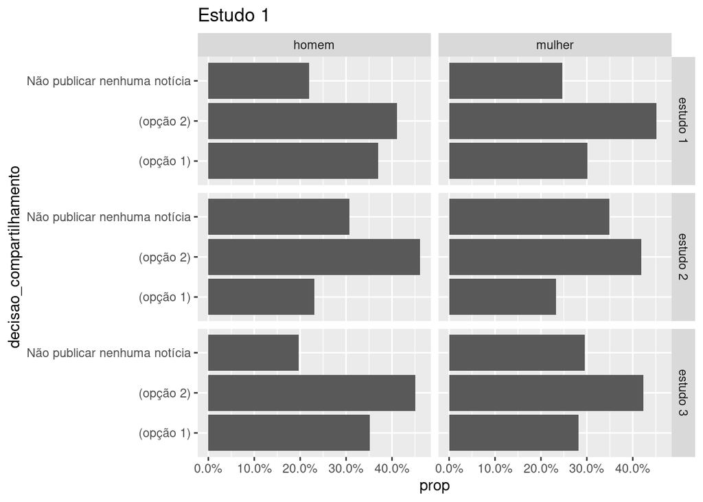

```r
# Gênero influencia decisão de compartilhar?
# estudo 1

compartilhamento_3_estudos %>%
  filter(!is.na(decisao_compartilhamento),
         genero != "outros") %>%
  droplevels() %>%
  ggplot(aes(x=decisao_compartilhamento,  y = ..prop.., group = 1)) + geom_bar() +
  ggtitle("Estudo 1") + scale_y_continuous(labels = scales::percent) + coord_flip() +
  facet_grid(estudo ~ genero)
```

Embora haja variações entre estudos, tanto para homens quanto para mulheres, a opção 2 é a preferida nos três estudos. Portanto, gênero não parece ser uma variável de confusão relevante. Porém, pode ser uma variável moderadora imortante. Assim, vamos investigar se bolsonaristas e lulistas se comportam diferentemente, quando analisamos por gênero.

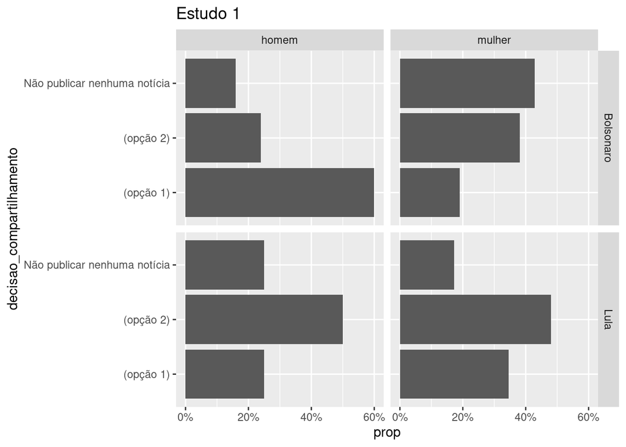

```r
# Gênero influencia decisão de compartilhar?
# estudo 1

compartilhamento_3_estudos %>%
  filter(estudo == "estudo 1",
         !is.na(decisao_compartilhamento),
         genero != "outros") %>%
  droplevels() %>%
  ggplot(aes(x=decisao_compartilhamento,  y = ..prop.., group = 1)) + geom_bar() +
  ggtitle("Estudo 1") + scale_y_continuous(labels = scales::percent) + coord_flip() +
  facet_grid(politico ~ genero)
```

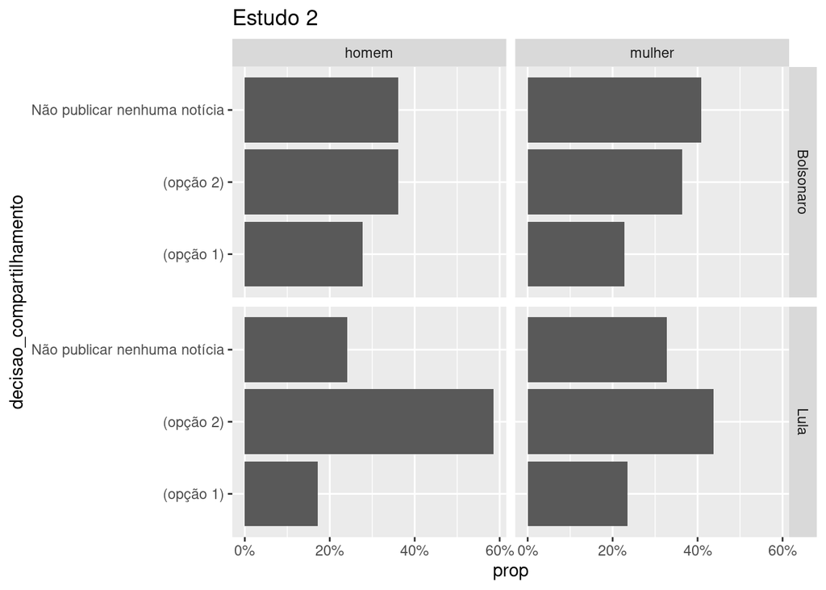

```r
# estudo 2
compartilhamento_3_estudos %>%
  filter(estudo == "estudo 2",
         !is.na(decisao_compartilhamento),
         genero != "outros") %>%
  droplevels() %>%
  ggplot(aes(x=decisao_compartilhamento,  y = ..prop.., group = 1)) + geom_bar() +
  ggtitle("Estudo 2") + scale_y_continuous(labels = scales::percent) + coord_flip() +
  facet_grid(politico ~ genero)
```

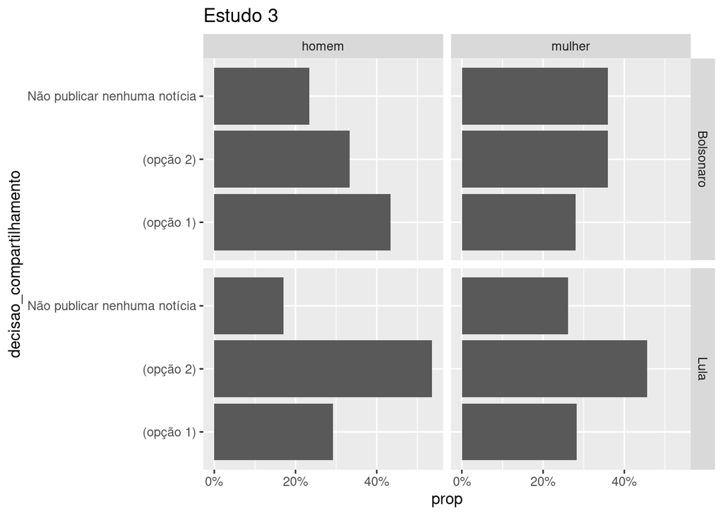

```r
# estudo 3
compartilhamento_3_estudos %>%
  filter(estudo == "estudo 3",
         !is.na(decisao_compartilhamento),
         genero != "outros") %>%
  droplevels() %>%
  ggplot(aes(x=decisao_compartilhamento,  y = ..prop.., group = 1)) + geom_bar() +
  ggtitle("Estudo 3") + scale_y_continuous(labels = scales::percent) + coord_flip() +
  facet_grid(politico ~ genero)
```

Gênero parece ser uma variável moderadora importante. No estudo 1, muda o comportamento de bolsonaristas completamente. Homens preferem a opção 1, enquanto para mulheres, esta é a opção menos escolhida. Para lulistas, a diferença é bem menos pronunciada.

Já no estudo 2, há pouca diferença entre homens e mulheres no grupo de bolsonaristas. Já para lulistas, a opção 2 é a preferida para mulheres e homens, mas muito mais para homens. Os dados do estudo 3 é bem similar ao estudo 2 para lulistas, enquanto que para Bolsonaristas parece haver pouca diferença entre homens e mulheres, ainda que não seja igual ao estudo 2.

Vamos agora analisar idade.

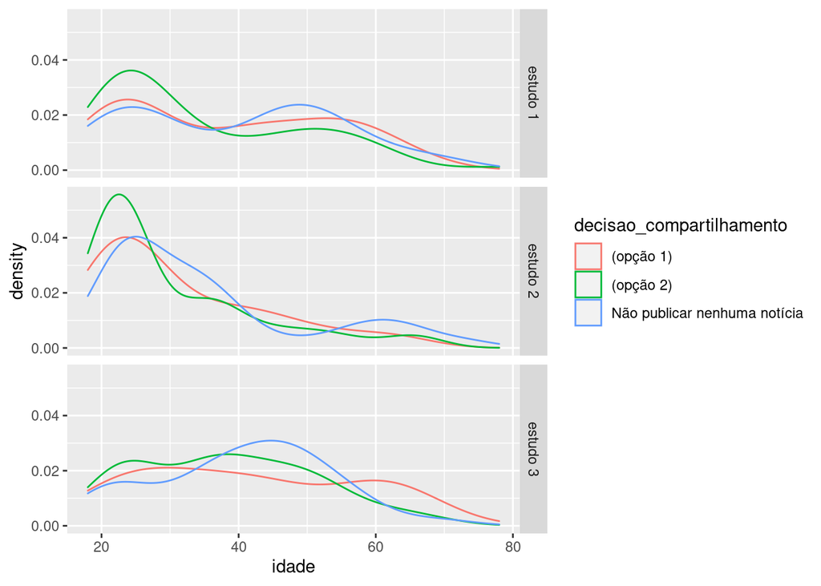

```r
# idade e compartilhamento

# estudo 1, 2 e 3
compartilhamento_3_estudos %>%
  filter(!is.na(decisao_compartilhamento),
         genero != "outros") %>%
  droplevels() %>%
  ggplot(aes(col=decisao_compartilhamento, x=idade)) + geom_density() +
  facet_grid(rows= vars(estudo))
```

Como vemos, a idade é um preditor importante da decisão de compartilhar, com a opção 2 sendo preferível pelos mais jovens, mas não entre os mais velhos. Isso significa que se a amostra for diferente entre lulistas e bolsonaristas com relação a idade, pode ser uma variável de confusão que devemos controlar.

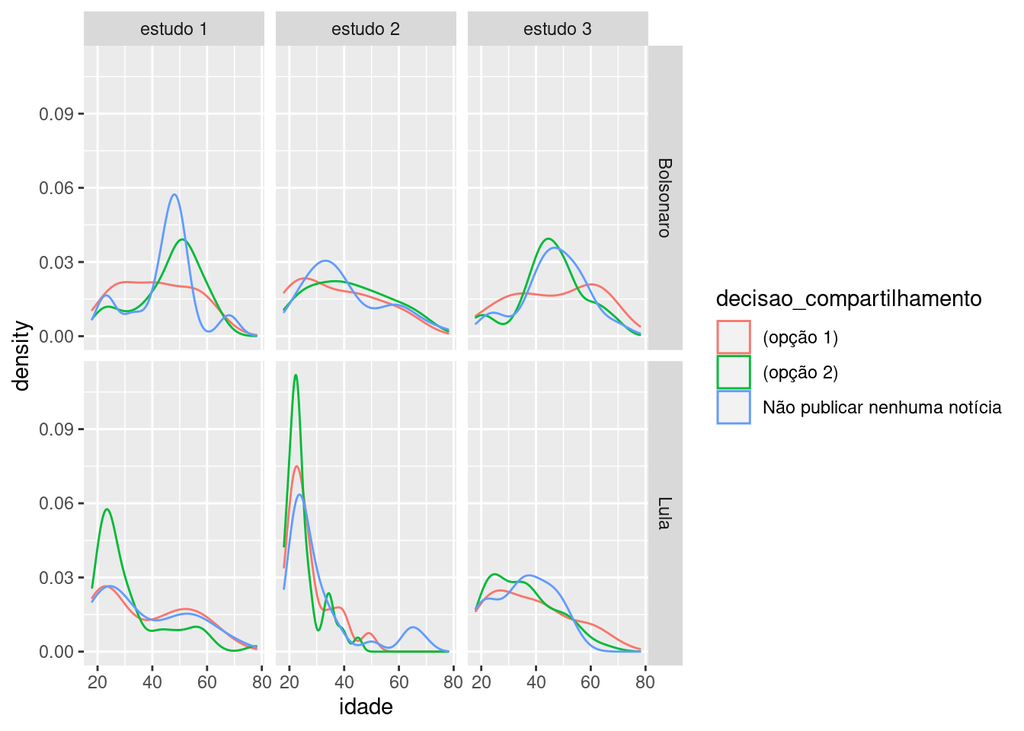

```r
# estudo 1, 2 e 3 por político e idade
compartilhamento_3_estudos %>%
  filter(!is.na(decisao_compartilhamento),
         genero != "outros") %>%
  droplevels() %>%
  ggplot(aes(col=decisao_compartilhamento, x=idade)) + geom_density() +
  facet_grid(politico ~ estudo)
```

```r
# opção 2 é bem maior entre mais jovens
```

Para mim parece difícil separar, apenas pela análise descritiva, os efeitos de idade e do bolsonarismo e lulismo. Parece que ambas as variáveis têm efeitos, mas é difícil ir além disso. A análise de regbressão será mais útil nesse sentido. Antes disso, porém, vamos olhar os scores de narcisismo e nacionalismo.

## scores

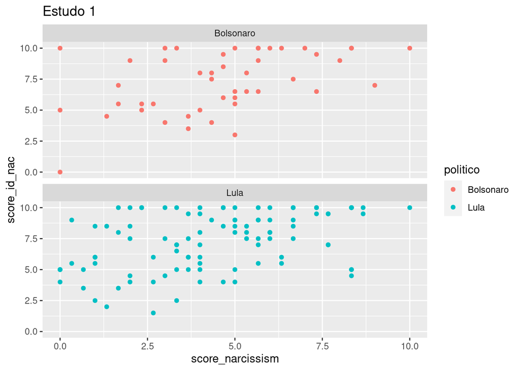

```r
# estudo 1
compartilhamento_3_estudos %>%
  filter(estudo == "estudo 1",
         !is.na(decisao_compartilhamento),
         genero != "outros") %>%
  droplevels() %>%
  ggplot(aes(x=score_narcissism, y=score_id_nac, color=politico)) + geom_point() +
  ggtitle("Estudo 1") +
  facet_wrap(vars(politico), nrow = 2)
```

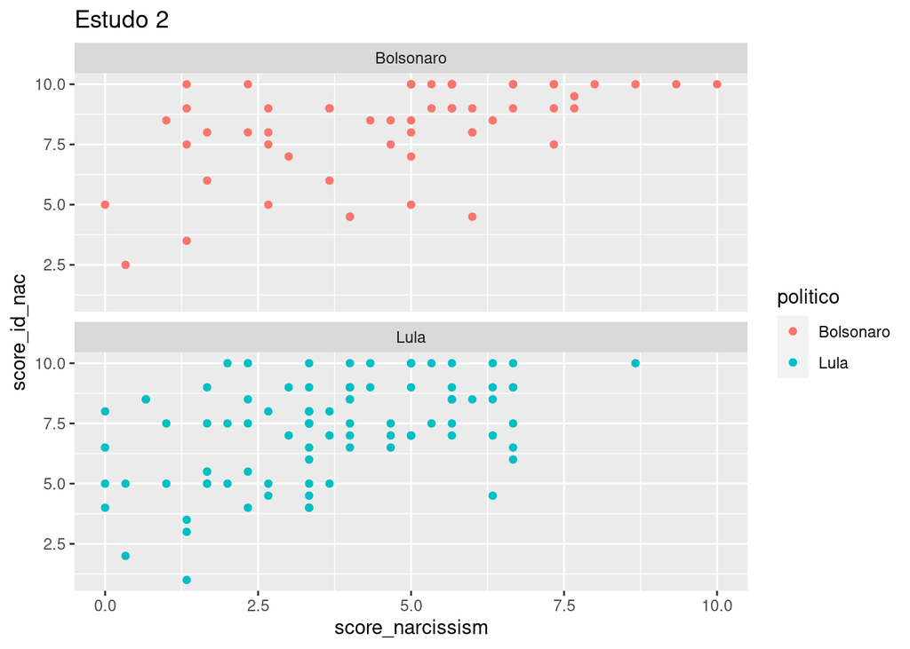

```r
# estudo 2
compartilhamento_3_estudos %>%
  filter(estudo == "estudo 2",
         !is.na(decisao_compartilhamento),
         genero != "outros") %>%
  droplevels() %>%
  ggplot(aes(x=score_narcissism, y=score_id_nac, color=politico)) + geom_point() +
  ggtitle("Estudo 2") +
  facet_wrap(vars(politico), nrow = 2)
```

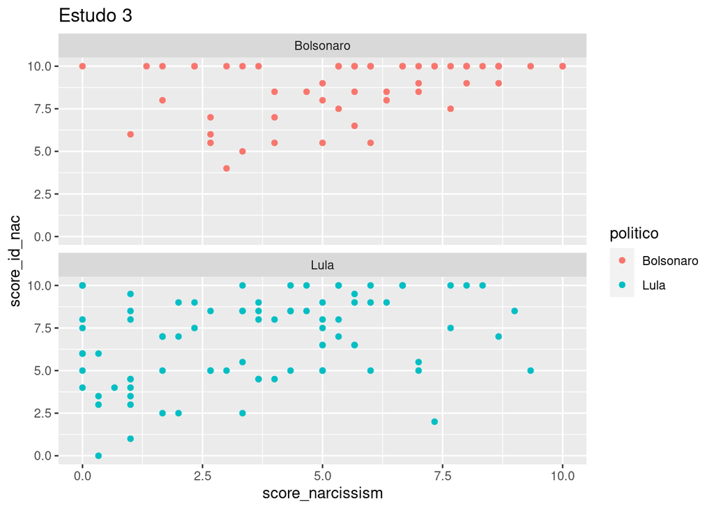

```r
# estudo 3
compartilhamento_3_estudos %>%
  filter(estudo == "estudo 3",
         !is.na(decisao_compartilhamento),
         genero != "outros") %>%
  droplevels() %>%
ggplot(aes(x=score_narcissism, y=score_id_nac, color=politico)) + geom_point() +
  ggtitle("Estudo 3") +
  facet_wrap(vars(politico), nrow = 2)
```

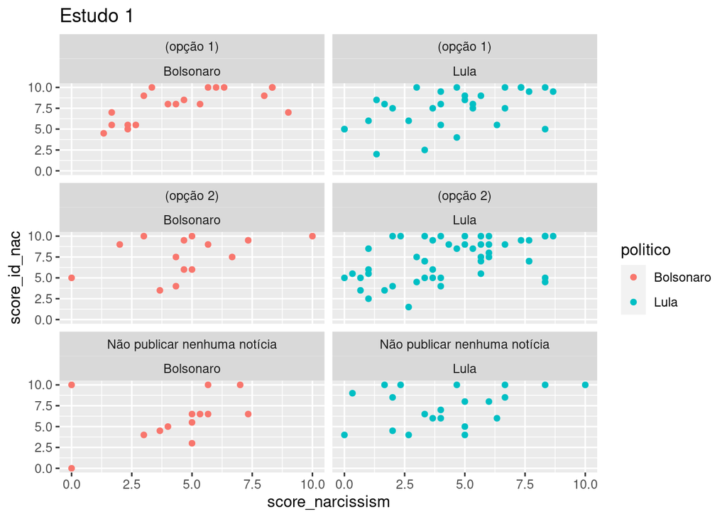

```r
## scores e decisão

# estudo 1
compartilhamento_3_estudos %>%
  filter(estudo == "estudo 1",
         !is.na(decisao_compartilhamento),
         genero != "outros") %>%
  droplevels() %>%
  ggplot(aes(x=score_narcissism, y=score_id_nac, color=politico)) + geom_point() +
  ggtitle("Estudo 1") +
  facet_wrap(vars(decisao_compartilhamento, politico), nrow = 3)
```

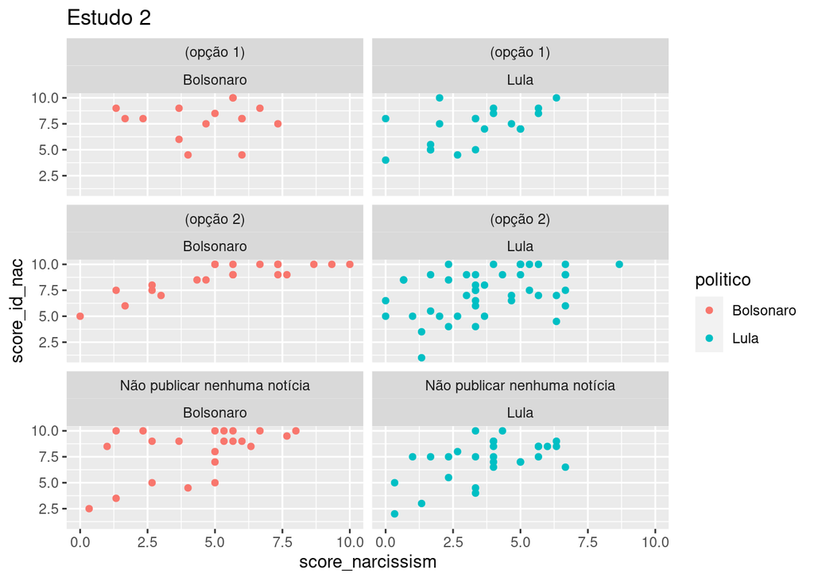

```r
# estudo 2
compartilhamento_3_estudos %>%
  filter(estudo == "estudo 2",
         !is.na(decisao_compartilhamento),
         genero != "outros") %>%
  droplevels() %>%
  ggplot(aes(x=score_narcissism, y=score_id_nac, color=politico)) + geom_point() +
  ggtitle("Estudo 2") +
  facet_wrap(vars(decisao_compartilhamento, politico), nrow = 3)
```

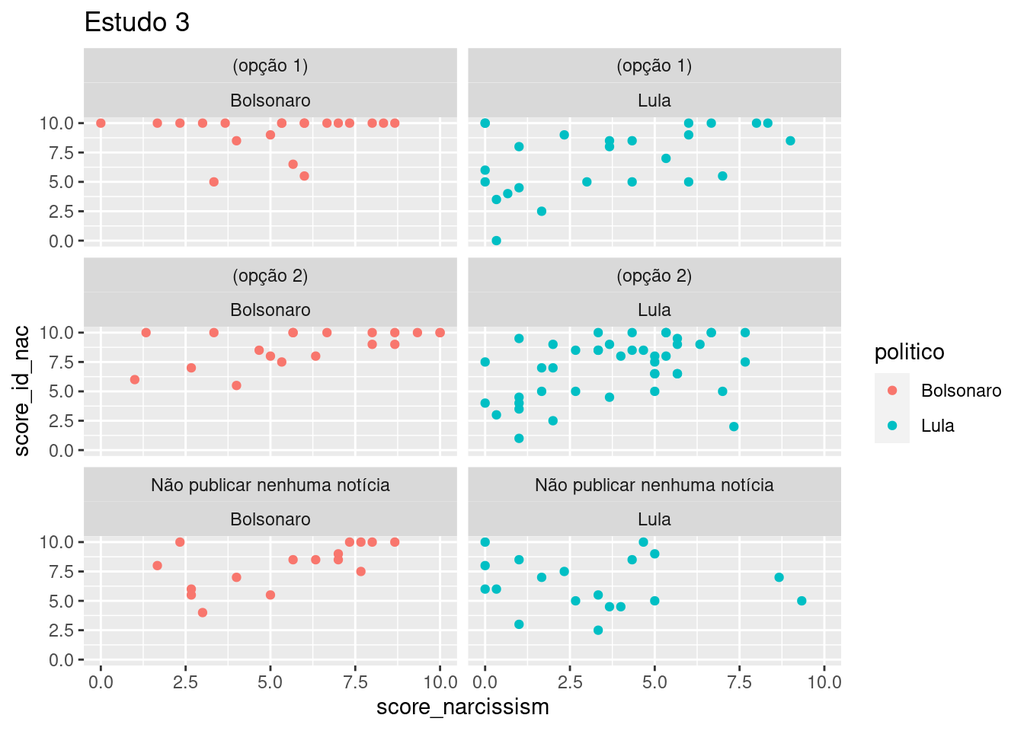

```r
# estudo 3
compartilhamento_3_estudos %>%
  filter(estudo == "estudo 3",
         !is.na(decisao_compartilhamento),
         genero != "outros") %>%
  droplevels() %>%
  ggplot(aes(x=score_narcissism, y=score_id_nac, color=politico)) + geom_point() +
  ggtitle("Estudo 3") +
  facet_wrap(vars(decisao_compartilhamento, politico), nrow = 3)
```

O próximo passo é utilizar análise de regressão para avançar na análise.